# Evaluación de uso aditivo funcional en el control de parásitos en salmones.

Jorge Pino Marambio

2022-05-10

## Descripcion Problema

La caligidosis es una de las infecciones ectoparasitarias más notorias y costosas que afectan a las especies de salmón silvestre y de cultivo, en todo el mundo. Las principales preocupaciones que suscita esta enfermedad, especialmente en la industria, son las aparicion de lesiones y stress en los peces, costos económicos asociados, y el impacto sobre la opinion publica sobre la gestión de la acuicultura. En general, el tratamiento de la caligidosis consiste en la aplicación de quimioterapia, pero debido a la pérdida de su eficacia se han aplicado nuevos métodos que incluyen prototipos de vacunas e inmunoestimulación mediante aditivos en la alimentación.

El objetivo de este trabajo fue evaluar el efecto de un aditivo funcional en la carga parasitaria en salmones Atlántico tratados 3, 6 y 9 días post infestación, durante 14 días. La evaluación del efecto se midió en los principales estadios del ciclo de vida. Tambien se evaluo el efecto residual del aditivo al día 28 post infestación, cuando toda la población alcanzó el estadio adulto.

## Objetivos especificos del AED

Como variable de estudio se define el conteo de los estadios de Caligus sobre los peces (“lice_number”), y como variables predictoras se definieron las siguientes: 1) Inicio de tratamiento (“Treatment”) 3DPI, 6DPI y 9DPI Días Post Infestación, y 2) la dosis adminstrada (“dose” = 0.09% y 0.2%) expresada como % de inclusión en el alimento. El número de observaciones del experimento es 8640.

[figure not shown]

Figura 1. Resumen grafico - Diseño experimental

## Resultados Análisis Exploratorio de Datos

```r
data_lice <- read_excel("sealice_data_dipR.xlsx", sheet= 1, na="NA")

data_lice$Counting <- as.factor(data_lice$Counting)
data_lice$Treatment <- as.factor(data_lice$Treatment)
data_lice$dose <- as.factor(data_lice$dose)
data_lice$Tank <- as.factor(data_lice$Tank)
data_lice$Fish <- as.factor(data_lice$Fish)

tidy_lice <- select(data_lice, Counting, Treatment,
                    dose, Tank, Fish,  copepodid, ch_1_2,
                    ch_3_4, male, female, grav_female)


Dat_parasitos <- tidy_lice %>% gather("life_stage","lice_number",6:11)
Dat_parasitos$life_stage <- as.factor(Dat_parasitos$life_stage)
Dat_parasitos$life_stage <- factor(Dat_parasitos$life_stage,
                                   levels=c("copepodid","ch_1_2",
                                            "ch_3_4", "male","female",
                                            "grav_female"))
Dat_parasitos$Counting <- factor(Dat_parasitos$Counting,
                                   levels=c("Post treatment","Final"))

DT::datatable(Dat_parasitos)
```

|  | Counting | Treatment | dose | Tank | Fish | life_stage | lice_number |
| --- | --- | --- | --- | --- | --- | --- | --- |
| 1 | Post treatment | 3DPI | 0.09 | A201 | 1 | copepodid | 7 |
| 2 | Post treatment | 3DPI | 0.09 | A201 | 2 | copepodid | 1 |
| 3 | Post treatment | 3DPI | 0.09 | A201 | 3 | copepodid | 1 |
| 4 | Post treatment | 3DPI | 0.09 | A201 | 4 | copepodid | 2 |
| 5 | Post treatment | 3DPI | 0.09 | A201 | 5 | copepodid | 2 |
| 6 | Post treatment | 3DPI | 0.09 | A201 | 6 | copepodid | 1 |
| 7 | Post treatment | 3DPI | 0.09 | A201 | 7 | copepodid | 0 |
| 8 | Post treatment | 3DPI | 0.09 | A201 | 8 | copepodid | 0 |
| 9 | Post treatment | 3DPI | 0.09 | A201 | 9 | copepodid | 0 |
| 10 | Post treatment | 3DPI | 0.09 | A201 | 10 | copepodid | 1 |

[output cut: 8630 more lines]

En general, se generaron un total de 8640 observación en data frame (Tabla 1), distribuídas 720 observaciones por combinación de varialbles predictoras y tiempo de muestreo.

```r
Tabla_1 <- Dat_parasitos %>% group_by(Counting, dose, Treatment) %>%
  summarise(n=n(), max = max(lice_number),
            median=median(lice_number),
            mean=mean(lice_number),
            sd = sd(lice_number), .groups = "drop")
pander(Tabla_1 , caption = "Tabla 1. Resumen del numero de observaciones del dataframe")
```

Tabla 1. Resumen del numero de observaciones del dataframe

| Counting | dose | Treatment | n | max | median | mean | sd |
| --- | --- | --- | --- | --- | --- | --- | --- |
| Post treatment | 0.09 | 3DPI | 720 | 12 | 0 | 0.7542 | 1.64 |
| Post treatment | 0.09 | 6DPI | 720 | 17 | 0 | 1.364 | 2.455 |
| Post treatment | 0.09 | 9DPI | 720 | 32 | 0 | 2.389 | 3.566 |
| Post treatment | 0.2 | 3DPI | 720 | 25 | 0 | 1.418 | 3.484 |
| Post treatment | 0.2 | 6DPI | 720 | 5 | 0 | 0.2792 | 0.6701 |
| Post treatment | 0.2 | 9DPI | 720 | 20 | 0 | 2.318 | 3.242 |
| Final | 0.09 | 3DPI | 720 | 2 | 0 | 0.01944 | 0.1656 |
| Final | 0.09 | 6DPI | 720 | 5 | 0 | 0.2306 | 0.6282 |
| Final | 0.09 | 9DPI | 720 | 37 | 2 | 3.263 | 4.72 |
| Final | 0.2 | 3DPI | 720 | 2 | 0 | 0.01528 | 0.1336 |
| Final | 0.2 | 6DPI | 720 | 2 | 0 | 0.025 | 0.1649 |
| Final | 0.2 | 9DPI | 720 | 22 | 1 | 2.343 | 2.955 |

Estamos en presencia de un experimento que contiene variables aleatorias discretas, aquellas que son número contable de valores; en este caso el conteo de piojos por pez. La variable aleatoria discreta, la cual tiene una funcion de distribucion No es normal, denominada Binomial negativa. La función de distribución para el caso de este ensayo tiene una asimetria derecha (Figura 1).

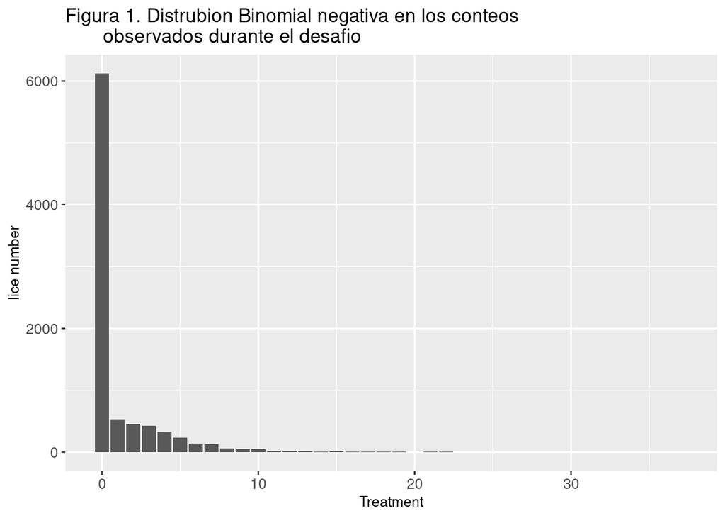

```r
my_theme = theme(axis.title.x=element_text(size = 10),
                 axis.text.x=element_text(size=10),
                 axis.title.y=element_text(size=10),
                 axis.text.y=element_text(size=10))

barT <- Dat_parasitos %>%
  ggplot(., aes(x=lice_number))+my_theme+
  geom_bar()+theme(legend.position = "top")+
  labs(title="Figura 1. Distrubion Binomial negativa en los conteos
       observados durante el desafio")+labs(x="Treatment",y="lice number")
barT
```

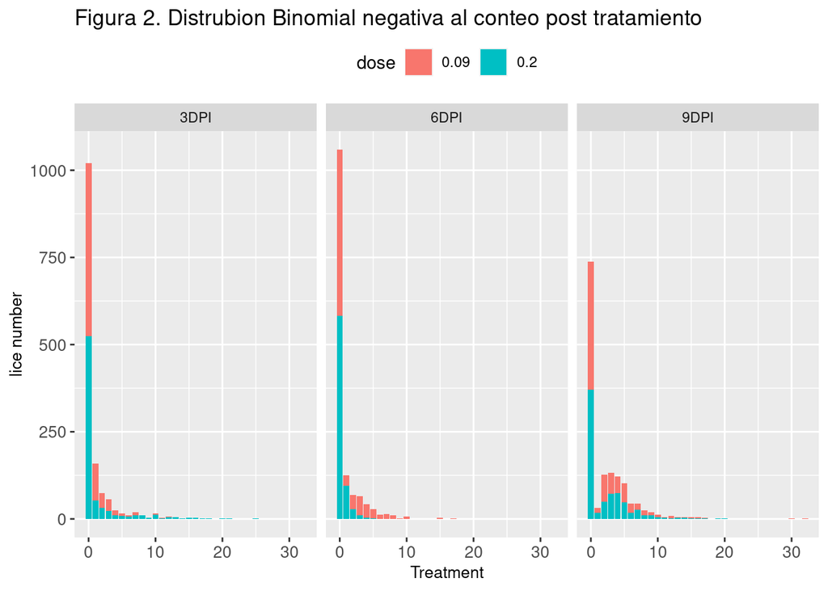

```r
barPT <- Dat_parasitos %>% filter(Counting == "Post treatment") %>%
  ggplot(., aes(x=lice_number, fill=dose))+my_theme+
  geom_bar()+facet_wrap(~Treatment)+
  labs(title="Figura 2. Distrubion Binomial negativa al conteo post tratamiento")+
  theme(legend.position = "top")+labs(x="Treatment",y="lice number")
barPT
```

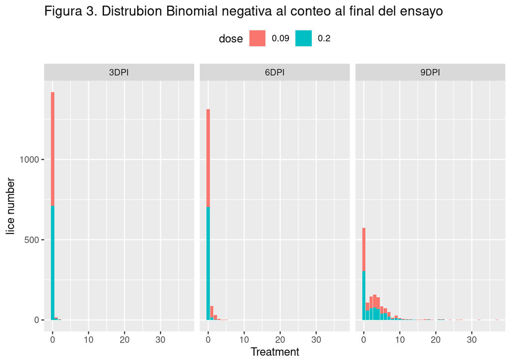

```r
barFinal <- Dat_parasitos %>% filter(Counting == "Final") %>%
  ggplot(., aes(x=lice_number, fill=dose))+
  geom_bar()+facet_wrap(~Treatment)+
  theme(legend.position = "top")+labs(x="Treatment",y="lice number")+
  labs(title="Figura 3. Distrubion Binomial negativa al conteo al final del ensayo")
barFinal
```

La dispersion de las observaciones obtenidas durante el todo el experimento se puede visualidar en la figura 4. Este tipo de gráficos nos permite identificar valores atípicos. Además de conocer de una forma cómoda y rápida como el 50% de los valores centrales se distribuyen. Por defecto en la opcion geom_boxplot, los datos atipicos se visualizan de acuerdo a si los valores que van más allá de 1.5 veces el rango intercuartílico desde Q1 o Q3 (bordes de las cajas) son candidatos a ser valores atípicos, y se representan con un punto de color rojo.

Graficando en función de tiempo de muestreo, dosis, tratamiento. Se puede observar la presencia de datos atípicos a cada condición (Figura 5 y 6).

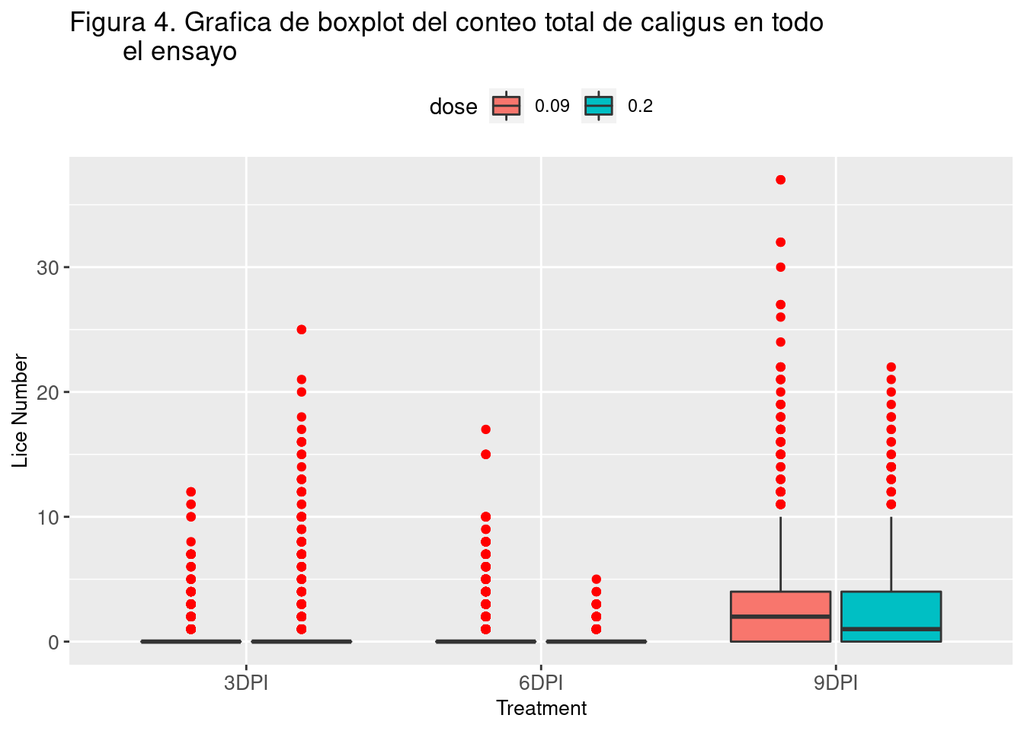

```r
box_Tot <- Dat_parasitos %>%
  ggplot(., aes(x=Treatment, y=lice_number, fill=dose ))+my_theme+
  geom_boxplot(outlier.colour="red")+labs(y="Lice Number")+
 # facet_grid(~life_stage)+
  labs(title="Figura 4. Grafica de boxplot del conteo total de caligus en todo
       el ensayo")+
  theme(legend.position = "top")
box_Tot
```

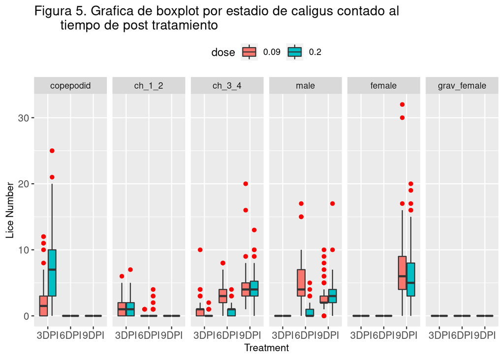

```r
box_1 <- Dat_parasitos %>% filter(Counting == "Post treatment") %>%
  ggplot(., aes(x=Treatment, y=lice_number, fill=dose ))+my_theme+
  geom_boxplot(outlier.colour="red")+labs(y="Lice Number")+
  facet_grid(~life_stage)+
  labs(title="Figura 5. Grafica de boxplot por estadio de caligus contado al
       tiempo de post tratamiento")+
  theme(legend.position = "top")
box_1
```

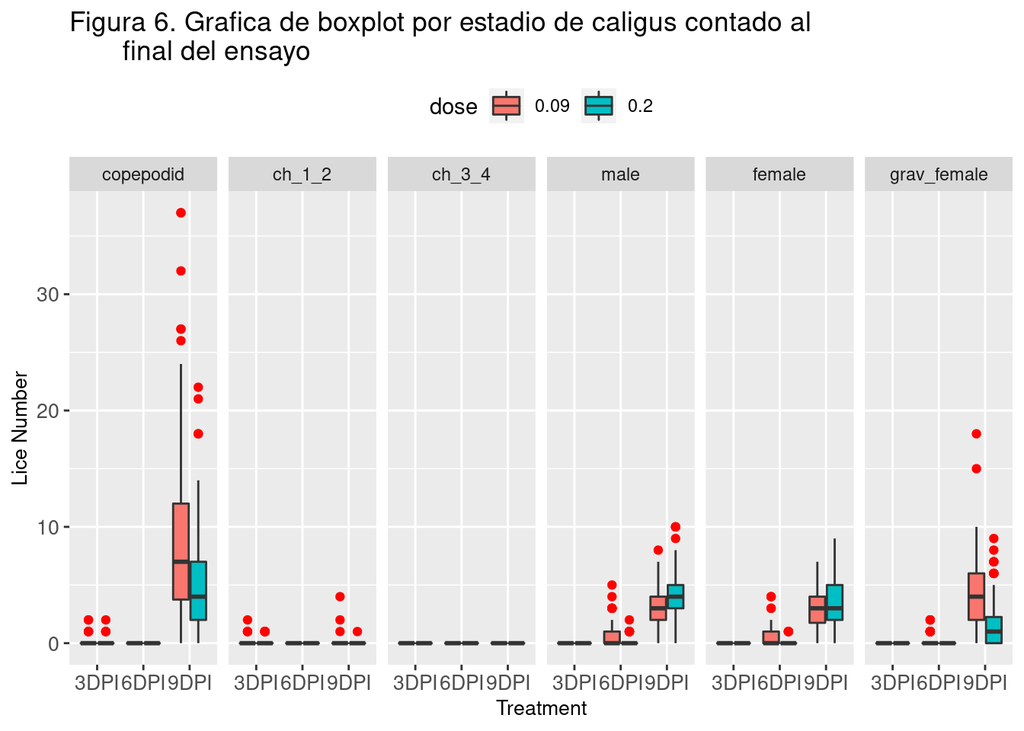

```r
box_2 <- Dat_parasitos %>% filter(Counting == "Final") %>%
  ggplot(., aes(x=Treatment, y=lice_number, fill=dose ))+my_theme+
  geom_boxplot(outlier.colour="red")+labs(y="Lice Number")+
  facet_grid(~life_stage)+
  labs(title="Figura 6. Grafica de boxplot por estadio de caligus contado al
       final del ensayo")+
  theme(legend.position = "top")
box_2
```

Utilizando la función boxplot.stats se puede conocer cuales son esos puntos determinardos como outlier. Utilizando la función which, podemos saber donde estan estas observaciones en el data_frame seleccionado.

```r
nout <- Dat_parasitos %>% filter(Counting == "Final", dose == "0.2", Treatment == "9DPI")
out <- boxplot.stats(nout$lice_number)$out
out_ind <- which(nout$lice_number %in% c(out))
out_ind
```

```
##  [1]   2   3   9  11  13  16  20  31  58 115
```

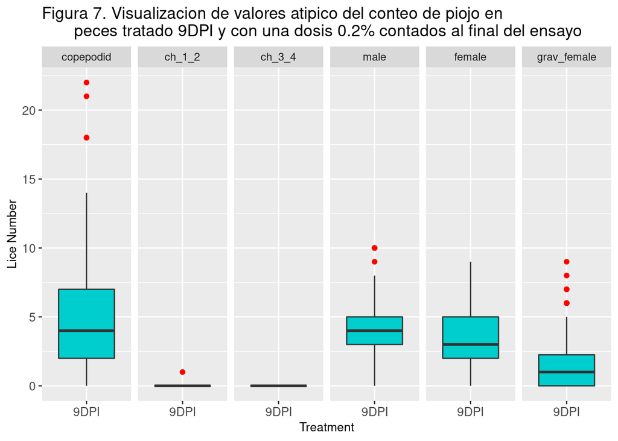

```r
box_3 <- Dat_parasitos %>% filter(Counting == "Final", dose=="0.2", Treatment=="9DPI") %>%
  ggplot(., aes(x=Treatment, y=lice_number))+my_theme+
  geom_boxplot(fill="cyan3", outlier.colour = "red")+labs(y="Lice Number")+
  facet_grid(~life_stage)+
  labs(title="Figura 7. Visualizacion de valores atipico del conteo de piojo en
       peces tratado 9DPI y con una dosis 0.2% contados al final del ensayo")+
  theme(legend.position = "top")
box_3
```

Las lineas del grafico de interacción indican el factor dosis, y sus dos niveles. No existe interacción entre las dosis dosis aplicada cuando el inicio del tratamiento se realiza entre los 3 y 6 DPI. Por otro lado al cambiar al tercer nivel de tratamiento (9DPI),se observa una interacción entre las variables, observándose una diferencia en el numero de piojos según la dosis aplicada (Figura 7).

La figura 8 visualiza de manera sencilla, cual es el factor que más esta afectando a la variable respuesta. En este sentido, la variable tratamiento, con sus tres nivel es la que mas afecta a la variable de respuesta asociada al número de parásitos. Si iniciamos el tratamiento lo mas cercano a la inicio de la infestación tendremos un efecto más importante en la reducción de piojos en el salmon infestado.

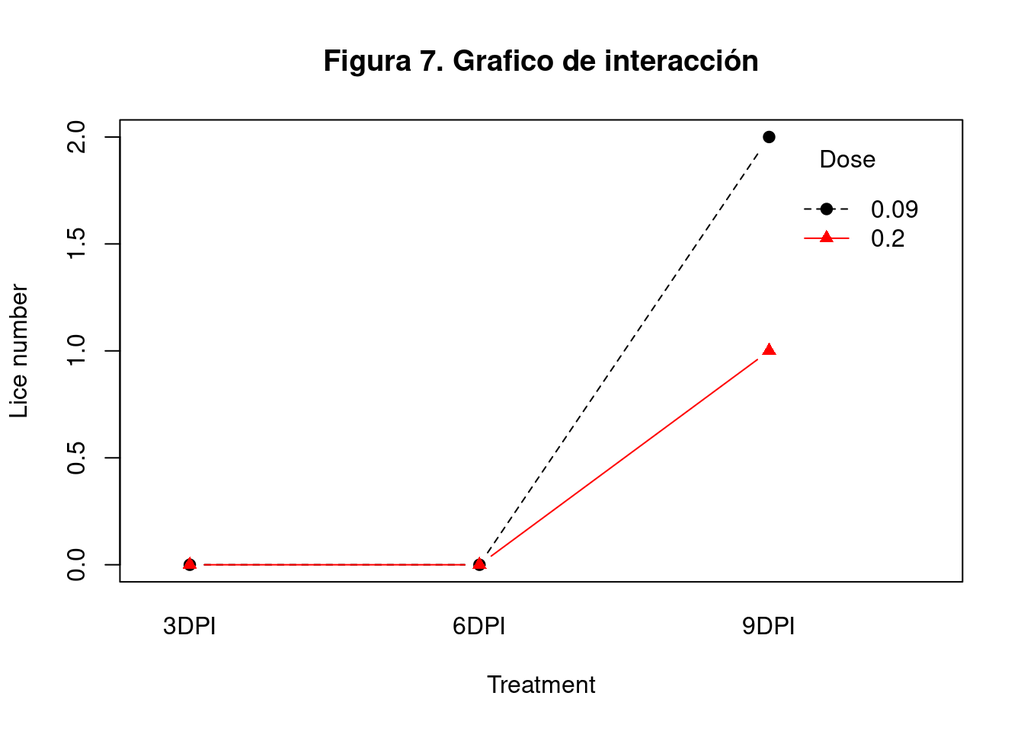

```r
interaction.plot(Dat_parasitos$Treatment, Dat_parasitos$dose,
                 Dat_parasitos$lice_number, fun=median,
                 main="Figura 7. Grafico de interacción", xlab="Treatment",
                 ylab="Lice number", trace.label = "Dose",
                 type="b", col= c("black", "red"),pch=c(19,17))
```

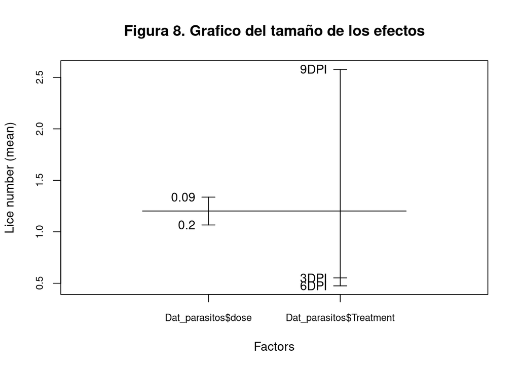

```r
plot.design(Dat_parasitos$lice_number ~
              Dat_parasitos$dose*Dat_parasitos$Treatment,
            xtick = T, main="Figura 8. Grafico del tamaño de los efectos",
            ylab = "Lice number (mean)",xlab = "Factors", cex.axis=0.8)
```